# Coefficient of determination for the ‘one to one’ line

by: [Valentin Stefan](https://github.com/valentinitnelav)

last update: 2018-05-27

Computing the coefficient of determination for the 1:1 line (intercept = 0 and slope = 1).

# 1 Make some data:

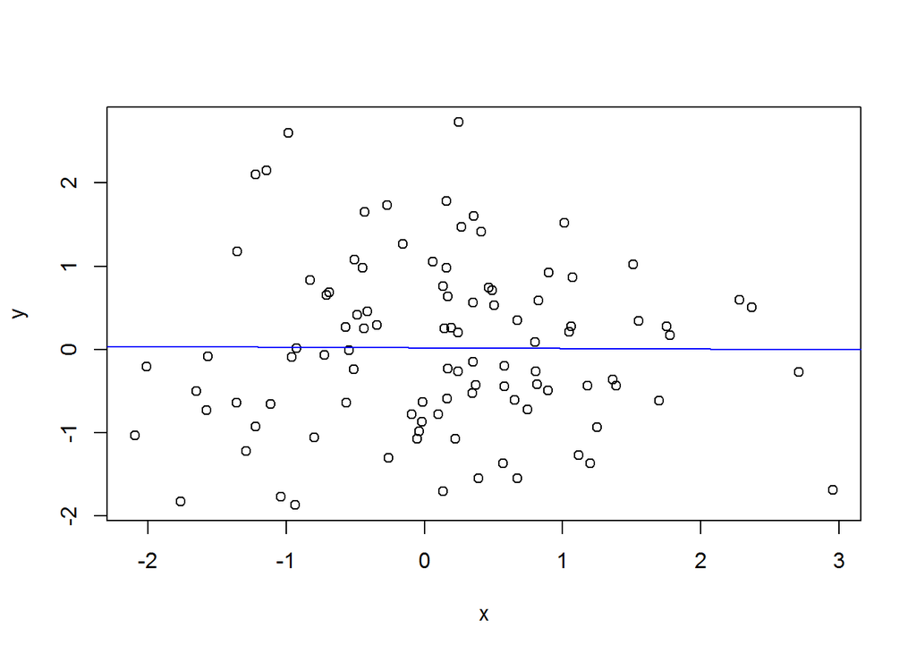

Some random data

```r
set.seed(2018)
y <- rnorm(n = 100, mean = 0, sd = 1)
x <- rnorm(n = 100, mean = 0, sd = 1)
plot(y ~ x)
# Add least squares regression line
abline(lm(y ~ x), col = "blue")
```

# 2 The 1:1 line

The [simple linear regression](https://en.wikipedia.org/wiki/Simple_linear_regression) is of the form `y = a + b*x + e`. For a 1:1 line the intercept a = 0 and the slope b = 1, so that `y = x + e`, where `e` are the errors (residuals/deviations from the 1:1 line). In R, a 1:1 line can be simply plotted with `abline(0,1)`.

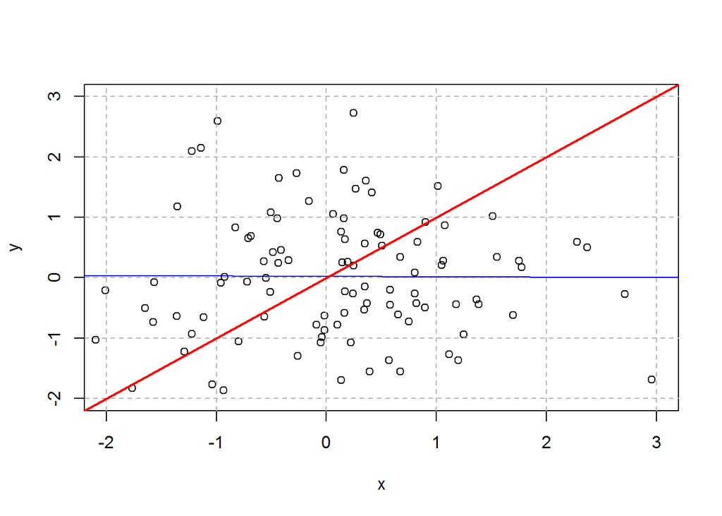

1:1 line in red and least squares regression line in blue

```r
plot(x, y, xlim = c(-2, 3), ylim = c(-2, 3))
# add grid
abline(h = seq(-2, 3, 1),
       v = seq(-2, 3, 1),
       lty = "dashed",
       col = "gray70")
abline(lm(y ~ x), col = "blue") # least squares regression line
abline(0, 1, col = "red", lwd = 2) # 1:1 line
```

Note that, for the 1:1 line, the errors (residuals) are simply the differences: `e = y - x`

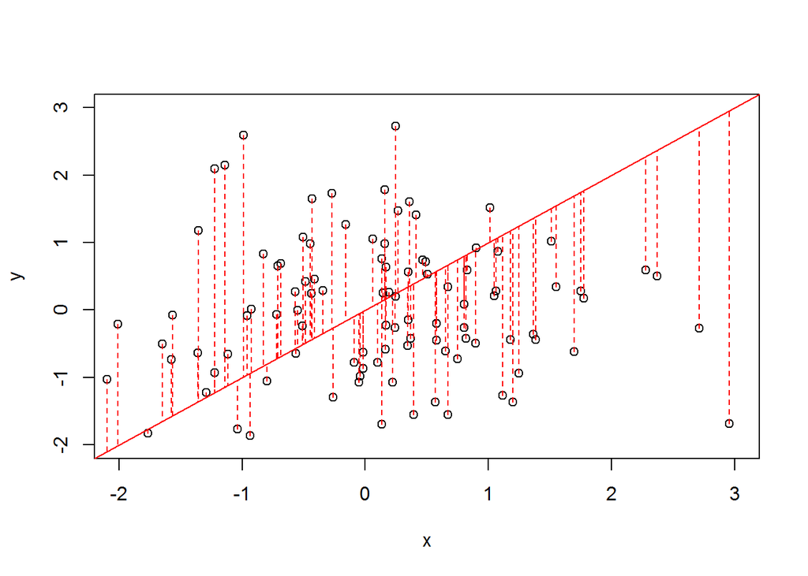

error (residuals/deviations from the 1:1 line)

```r
plot(x, y, xlim = c(-2, 3), ylim = c(-2, 3))
abline(0, 1, col = "red") # 1:1 line
segments(x0 = x,
         y0 = y,
         x1 = x,
         y1 = x, # y1 = y - e = y - y + x = x
         col = "red",
         lty = "dashed")
```

# 3 The coefficient of determination

The [coefficient of determination](https://en.wikipedia.org/wiki/Coefficient_of_determination) “is the proportion of the variance in the dependent variable that is predictable from the independent variable”.

Checking the [Wikipedia page](https://en.wikipedia.org/wiki/Coefficient_of_determination), we can see that “the most general definition of the coefficient of determination” is given in relation to the **unexplained variance** - the fraction of variance unexplained (FVU):

R<sup>2</sup> = 1 - FVU = 1 - SS<sub>res</sub> ⁄ SS<sub>tot</sub>

where FVU is the sum of squares of residuals (SS<sub>res</sub>) divided by the total sum of squares (SS<sub>tot</sub>)

SS<sub>res</sub> = ∑(y<sub>i</sub> - ŷ<sub>i</sub>)<sup>2</sup> = ∑e<sub>i</sub><sup>2</sup>

SS<sub>tot</sub> = ∑(y<sub>i</sub> - ȳ<sub>i</sub>)<sup>2</sup>

As already pointed above, for the 1:1 line, the errors (residuals) are the differences: `e = y - x`. Therefore, SS<sub>res</sub> can be written as:

SS<sub>res</sub> = ∑e<sub>i</sub><sup>2</sup> = ∑(y<sub>i</sub> - x<sub>i</sub>)<sup>2</sup>

The R implementation for the 1:1 line is:

```r
SS_res <- sum((y - x) ^ 2)
SS_tot <- sum((y - mean(y)) ^ 2)
1 - SS_res / SS_tot
```

```
## [1] -1.032755
```

Here we get a value outside of the usual range 0 to 1 because the 1:1 line fits the data worse than just the ȳ horizontal line, that is, the line of intercept = ȳ and slope = 0, for which R<sup>2</sup> = 0 because ȳ<sub>i</sub> = ŷ<sub>i</sub>, which makes SS<sub>res</sub> = SS<sub>tot</sub>.

# 4 Extra thoughts

## 4.1 Flipping axis

We can put the above in a simple R function:

```r
r2_1to1 <- function(xx, yy) {
  SS_res <- sum((yy - xx) ^ 2)
  SS_tot <- sum((yy - mean(yy)) ^ 2)
  r2 <- 1 - SS_res / SS_tot
  return(r2)
}
r2_1to1(x, y)
```

```
## [1] -1.032755
```

```r
r2_1to1(y, x)
```

```
## [1] -1.014109
```

Note that, if we inverse x and y we get a different coefficient of determination (R squared) for the 1:1 line. However, if fitting the usual simple linear regression (no constraints on intercept or slope), then we get the same coefficient of determination when we switch x with y.

```r
# R squared doesn't change in case of least square line when switching x with y
summary(lm(y ~ x))$r.squared
```

```
## [1] 4.091335e-05
```

```r
summary(lm(x ~ y))$r.squared
```

```
## [1] 4.091335e-05
```

```r
all.equal(summary(lm(y ~ x))$r.squared,
          summary(lm(x ~ y))$r.squared)
```

```
## [1] TRUE
```

## 4.2 Another way - `lm(y ~ 0 + offset(x))`

Another way of getting to the R squared is to fit a linear model with a fixed slope as explained [here](http://r.789695.n4.nabble.com/how-fit-linear-model-with-fixed-slope-td3007271.html):

```r
lm_1to1 <- lm(y ~ 0 + offset(1*x))
# 1* - indicates that the slope is constrained to 1; can simply be offset(x)
# 0  - indicates that there is no intercept (-1 has the same effect)
# Note, if you need a certain value for the intercept, check https://stackoverflow.com/a/7333292/5193830
summary(lm_1to1) # is ok to see "No Coefficients" since they are constrained to 0 and 1
```

```
##
## Call:
## lm(formula = y ~ 0 + offset(1 * x))
##
## Residuals:
##     Min      1Q  Median      3Q     Max
## -4.6403 -1.0285 -0.0701  0.8686  3.5844
##
## No Coefficients
##
## Residual standard error: 1.438 on 100 degrees of freedom
```

```r
summary(lm_1to1)$r.squared # this is not valid!
```

```
## [1] 0
```

```r
# Another function to compute R squared
r2 <- function(yy, model) {
  SS_res <- sum(model$residuals ^ 2) # residuals are taken from the model
  SS_tot <- sum((yy - mean(yy)) ^ 2)
  r2 <- 1 - SS_res / SS_tot
  return(r2)
}

# This tests that function r2() is working properly
all.equal(summary(lm(y ~ x))$r.squared,
          r2(y, lm(y ~ x)))
```

```
## [1] TRUE
```

```r
# This is R squared for the 1:1 fit.
# Result identical with what we did previously using r2_1to1() function.
r2(y, lm_1to1)
```

```
## [1] -1.032755
```

```r
all.equal(r2(y, lm_1to1),
          r2_1to1(x, y))
```

```
## [1] TRUE
```